# Trabajo Primer Parcial

Juan Carlos Hinojosa Peredo

Fecha de Entrega: 22/04/2020

### Preparación de datos

```r
> library(readxl)
>
> datospib <- read_excel("PIB_TRABAJO_EXAMEN_1_BIE_BIE20200318205927.xls",
+                        range = "A10:B170")
> datospib.ajuste <- datospib[69:152, ] #Datos de 1997/01 a 2017/04
>
> pib <- ts(datospib.ajuste[,2], start = c(1997,1), frequency = 4)
```

### Analisis Exploratorio

Gráfica serie de tiempo *pib* del 1997/01 al 2017/04

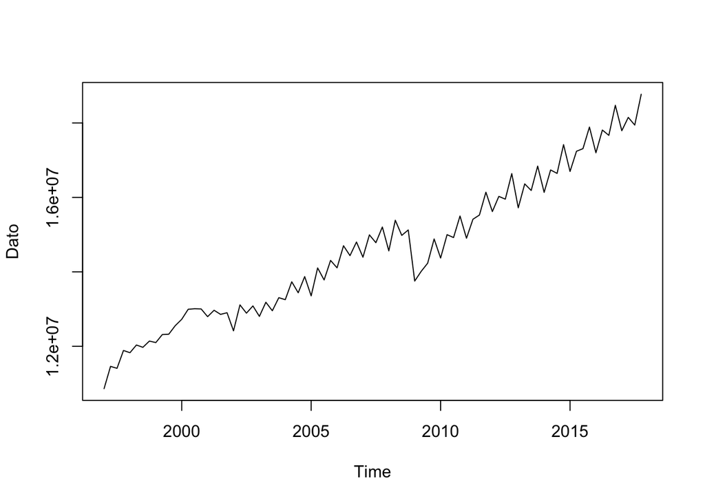

```r
> plot(pib)
```

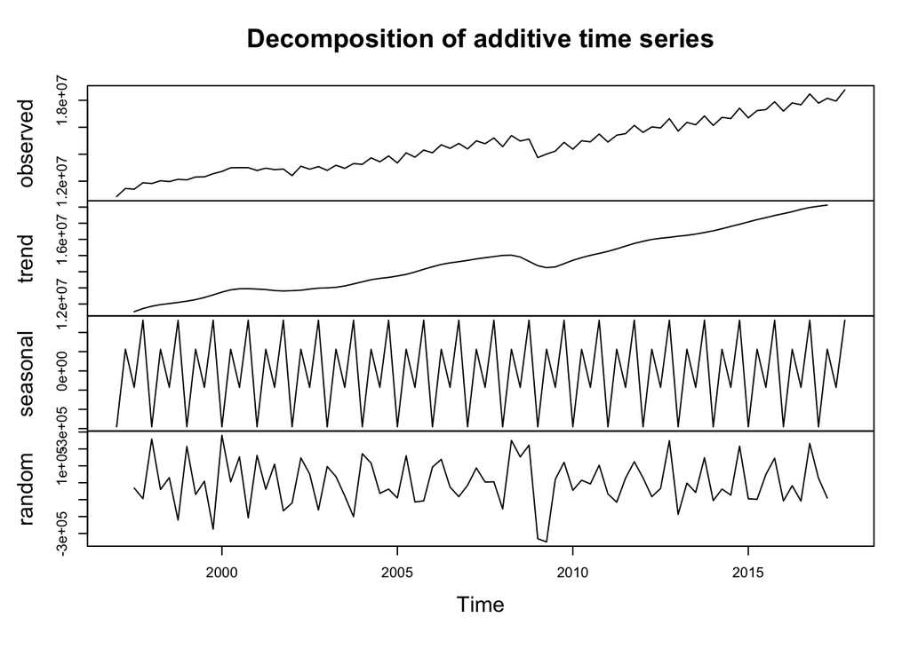

```r
> plot(decompose(pib))
```

Observamos una clara tendencia deterministica pero al parecer no estocástica por lo que no es necesario aplicar logaritmo para estabilzar la varianza. Hay indicios de raiz unitaria y efectos estacionales muy claros. Hay un cambio estructural por la crisis del 2008.

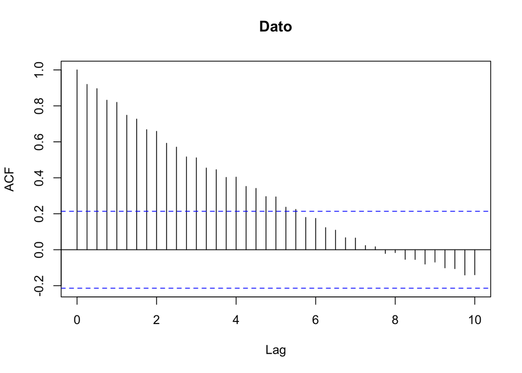

```r
> acf(pib, lag.max = 40)
```

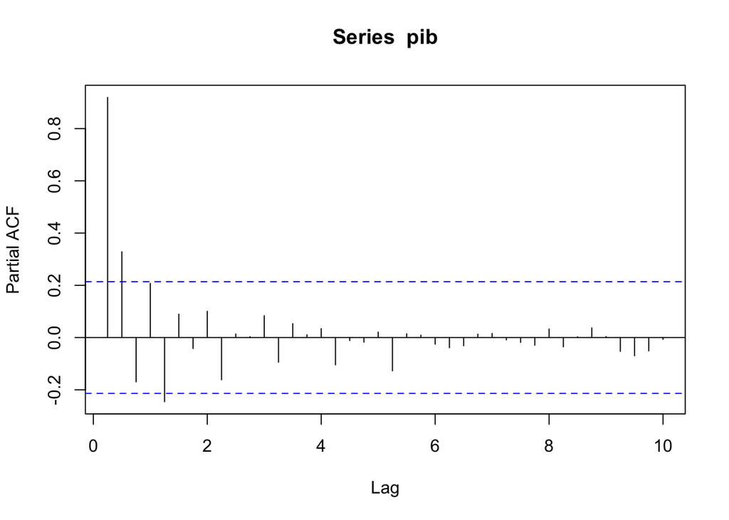

```r
> pacf(pib, lag.max = 40)
```

La **Función de Autocorrelación (ACF)** nos muestra una fuerte correlación con los valores pasados lo que puede ser indicio de raíz unitaría si los coeficientes de lags recientes son cercanos a uno.

La **Función de Autocorrelación Parcial (PACF)** nos dice que hay una relación de casi *uno a uno* con la observación de lag *t-1*, lo que refurza la sospecha de raíz unitaria que nos despertó la gráfica de la ACF.

Observamos el comportamiento de la serie *pib* con diferenciación de orden 1:

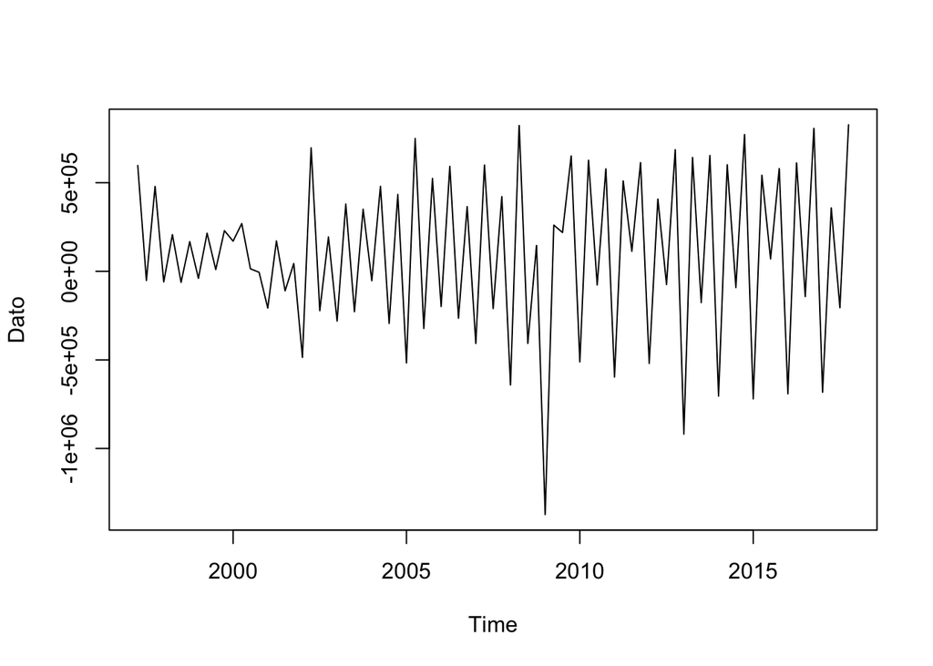

```r
> d.pib <- diff(pib)
> plot(d.pib)
```

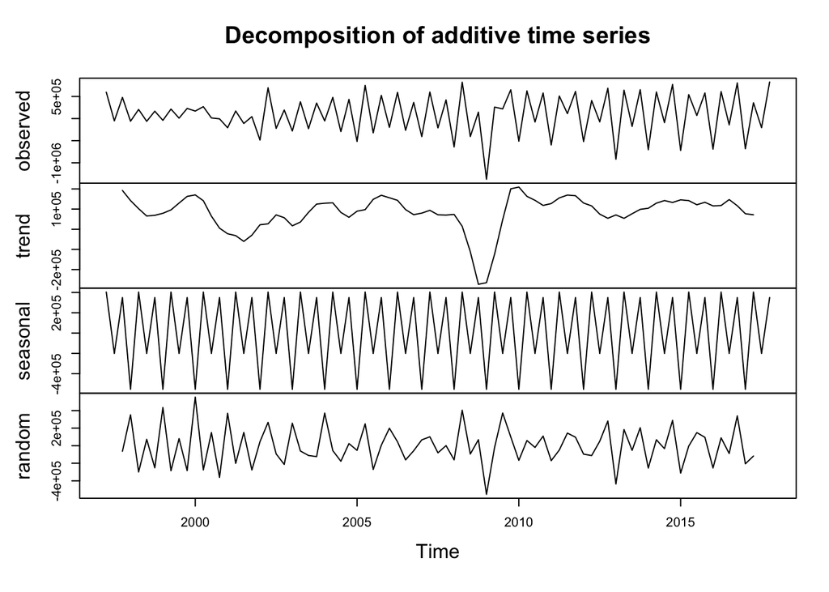

```r
> plot(decompose(d.pib))
```

Podemos ver que la tendencia desapareció pero aún hay fuertes efectos estacionales.

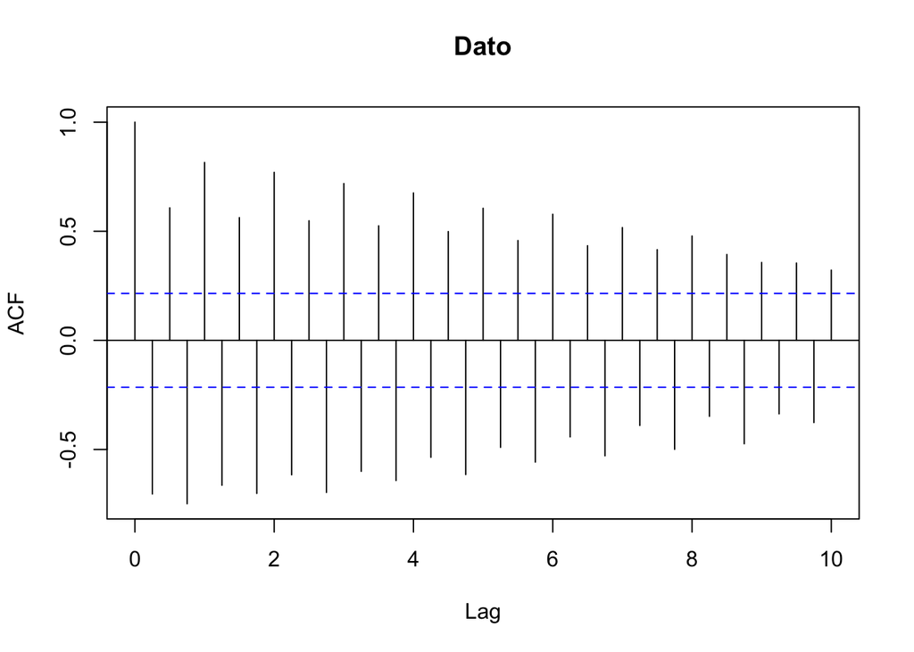

```r
> acf(d.pib, lag.max = 40)
```

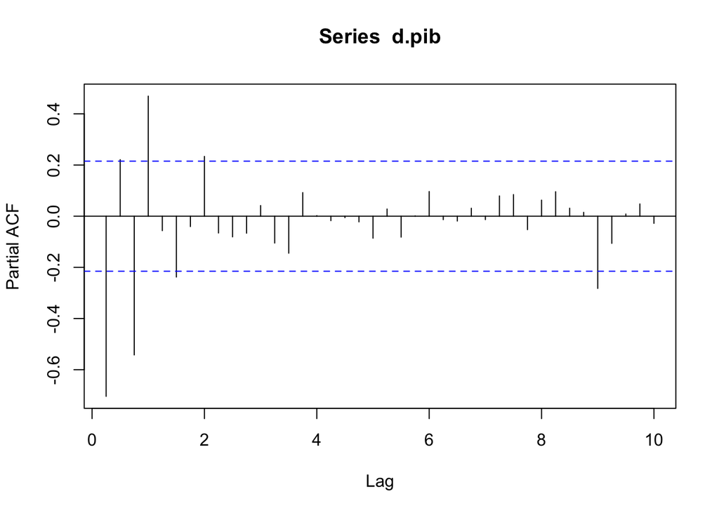

```r
> pacf(d.pib, lag.max = 40)
```

El la gráfica de la **Función de Autocorrelación (ACF)** vemos que $\Delta pib_t$ aún depende mucho de las observaciones pasadas pero los coeficientes de las observaciones parecen ser distintos de $1$.

**Función de Autocorrelación Parcial (PACF)** no muestra coeficientes de los regresores cercanos a $1$ así que al parecer la serie *d.pib* no tiene raices unitarias.

Procedemos a analizar la serie solo con una diferencia estacional:

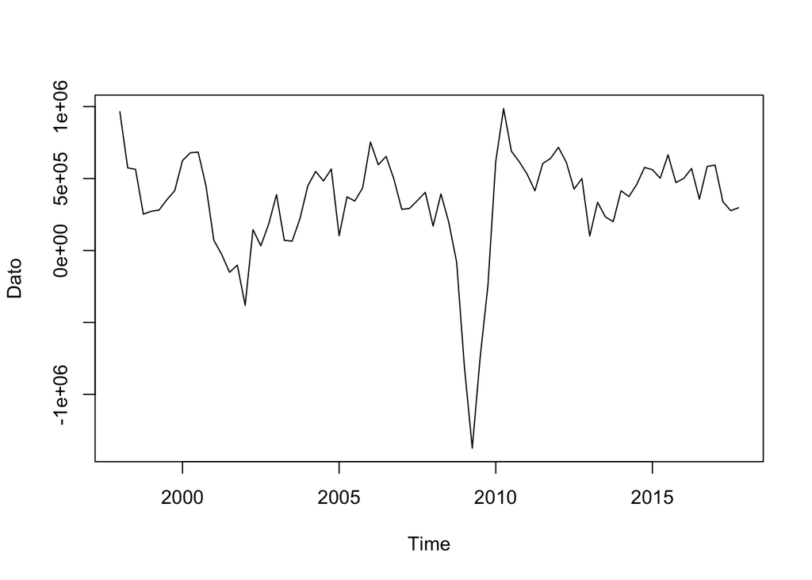

```r
> sd.pib <- diff(pib, lag = 4)
> plot(sd.pib)
```

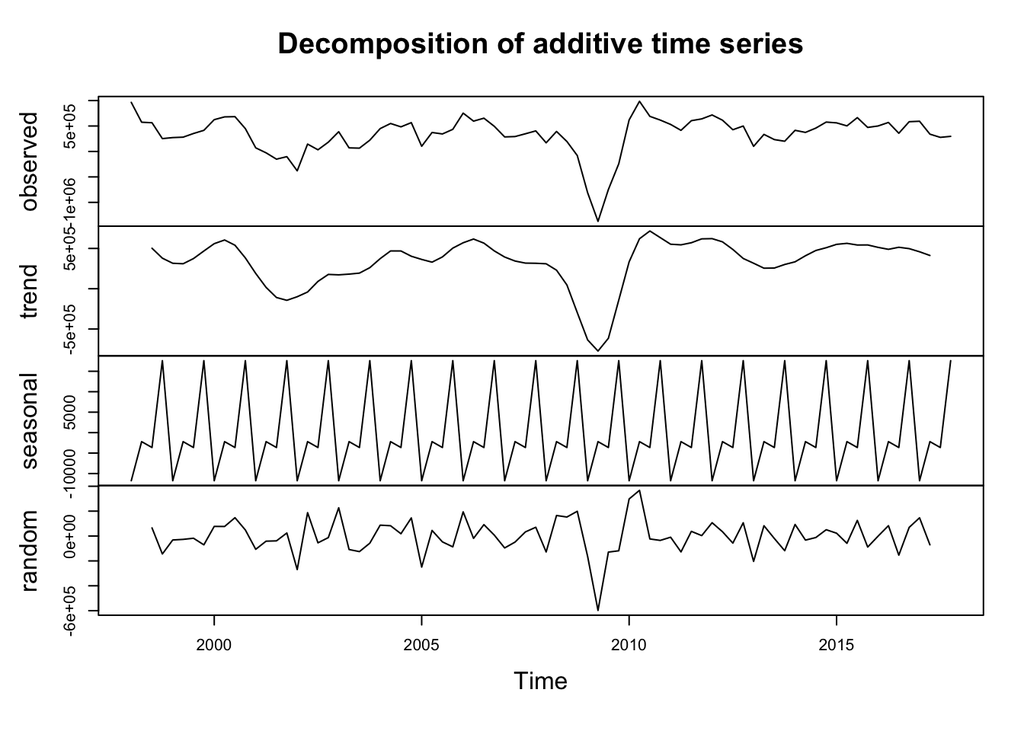

```r
> plot(decompose(sd.pib))
```

Nos damos cuenta que con una diferencia estacional nos deshacemos de la tendencia y de los efectos estacionales.

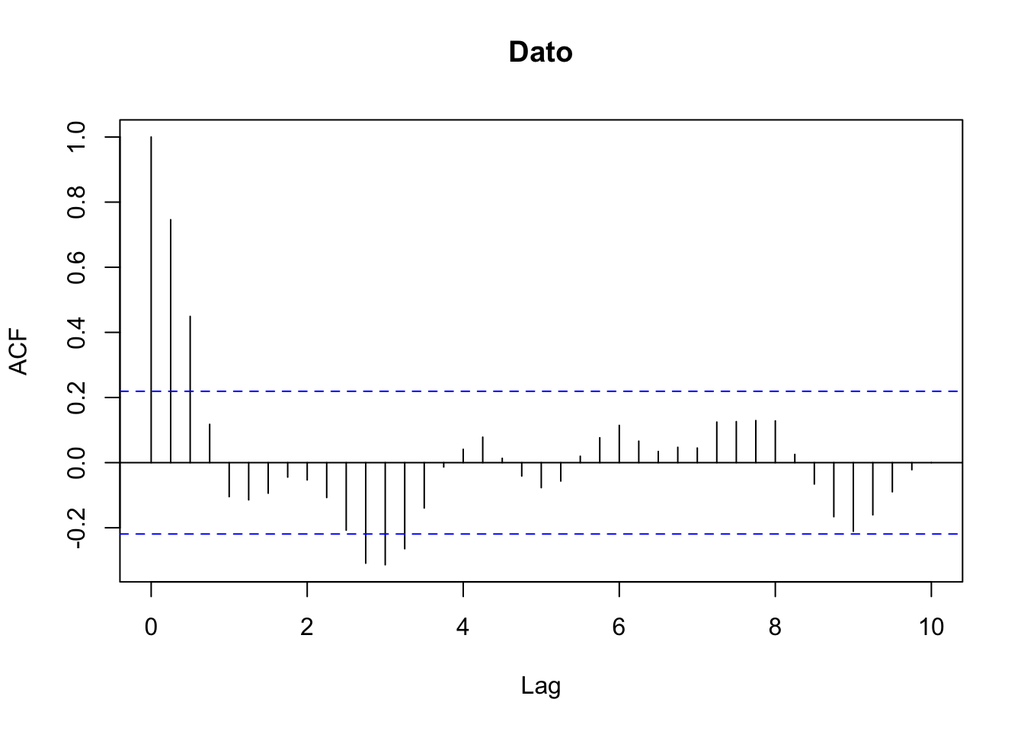

```r
> acf(sd.pib, lag.max = 40)
```

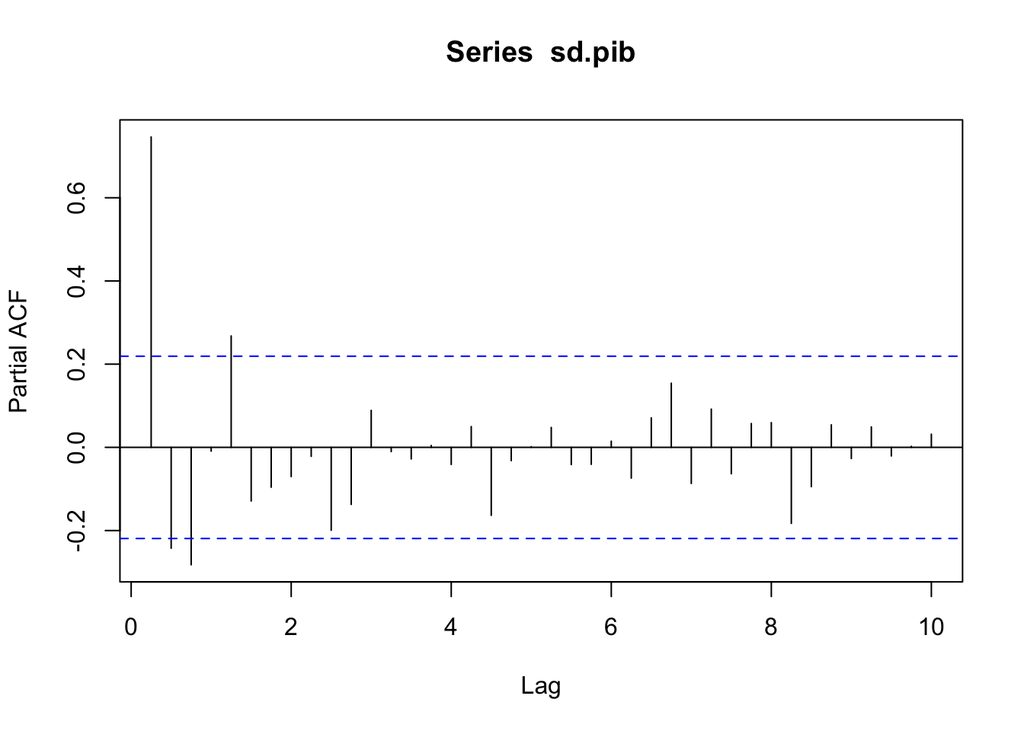

```r
> pacf(sd.pib, lag.max = 40)
```

En ambas gráficas nos percatamos de que los valores de los coeficientes de la regreción de autocorrelación parcial así como de la función de autocorrelación son relativamente distintos de $1$.

#### Conclusiones Análisis Exploratorio:

- Tendencia determinística no estocastica muy clara
- Indicios de raíz unitaria (ACF y PACF)
- Necesidad de una diferencia no-estacional
- Necesidad de una diferencia estacional
- Tal vez es necesaria una variable indicadora para capturar los cambios estructurales de la crisis económica del 2008 y de la burbuja *dotcom* de 1994 al 2001.

### Pruebas de Raiz Unitaria Dickey-Fuller

Primero haremos el test de Perron para definir el número de lags $M^*$. Proponemos arbitrariamente el valor $M^*=4$ ya que las observaciones de la serie *pib* son de frecuencia cuatrimestral.

```r
> library(urca)
> summary(ur.df(pib, type = "trend", lags = 4))
```

```
##
## ###############################################
## # Augmented Dickey-Fuller Test Unit Root Test #
## ###############################################
##
## Test regression trend
##
##
## Call:
## lm(formula = z.diff ~ z.lag.1 + 1 + tt + z.diff.lag)
##
## Residuals:
##     Min      1Q  Median      3Q     Max
## -786257  -93185   13388  128728  431701
##
## Coefficients:
##               Estimate Std. Error t value Pr(>|t|)
## (Intercept)  2.329e+06  8.584e+05   2.714  0.00832 **
## z.lag.1     -2.044e-01  7.648e-02  -2.673  0.00930 **
## tt           1.637e+04  5.844e+03   2.802  0.00653 **
## z.diff.lag1  7.561e-03  1.132e-01   0.067  0.94693
## z.diff.lag2  3.128e-02  9.776e-02   0.320  0.74991
## z.diff.lag3 -2.546e-01  9.607e-02  -2.651  0.00987 **
## z.diff.lag4  6.066e-01  9.735e-02   6.231 2.79e-08 ***
## ---
## Signif. codes:  0 '***' 0.001 '**' 0.01 '*' 0.05 '.' 0.1 ' ' 1
##
## Residual standard error: 214800 on 72 degrees of freedom
## Multiple R-squared:  0.8135, Adjusted R-squared:  0.7979
## F-statistic: 52.33 on 6 and 72 DF,  p-value: < 2.2e-16
##
##
## Value of test-statistic is: -2.6726 4.7618 4.0259
##
## Critical values for test statistics:
##       1pct  5pct 10pct
## tau3 -4.04 -3.45 -3.15
## phi2  6.50  4.88  4.16
## phi3  8.73  6.49  5.47
```

El $|t_{.99}| = 6.231 > 1.6$; no podemos empezar la prueba aquí, proponemos una $M^{**}>M^*$:

```r
> summary(ur.df(pib, type = "trend", lags = 5))
```

```
##
## ###############################################
## # Augmented Dickey-Fuller Test Unit Root Test #
## ###############################################
##
## Test regression trend
##
##
## Call:
## lm(formula = z.diff ~ z.lag.1 + 1 + tt + z.diff.lag)
##
## Residuals:
##     Min      1Q  Median      3Q     Max
## -775028  -93212    9808  134436  432899
##
## Coefficients:
##               Estimate Std. Error t value Pr(>|t|)
## (Intercept)  2.146e+06  9.259e+05   2.318   0.0234 *
## z.lag.1     -1.868e-01  8.280e-02  -2.256   0.0272 *
## tt           1.484e+04  6.305e+03   2.354   0.0214 *
## z.diff.lag1  5.140e-02  1.220e-01   0.421   0.6749
## z.diff.lag2  6.407e-03  1.142e-01   0.056   0.9554
## z.diff.lag3 -2.559e-01  9.988e-02  -2.562   0.0126 *
## z.diff.lag4  6.081e-01  1.030e-01   5.905 1.15e-07 ***
## z.diff.lag5 -8.414e-02  1.214e-01  -0.693   0.4907
## ---
## Signif. codes:  0 '***' 0.001 '**' 0.01 '*' 0.05 '.' 0.1 ' ' 1
##
## Residual standard error: 215900 on 70 degrees of freedom
## Multiple R-squared:  0.8165, Adjusted R-squared:  0.7982
## F-statistic: 44.51 on 7 and 70 DF,  p-value: < 2.2e-16
##
##
## Value of test-statistic is: -2.2555 4.4738 2.834
##
## Critical values for test statistics:
##       1pct  5pct 10pct
## tau3 -4.04 -3.45 -3.15
## phi2  6.50  4.88  4.16
## phi3  8.73  6.49  5.47
```

El $|t_{.99}| = 0.693 < 1.6$ entonces podemos empezar el test de Perron $5$ lags y empezar a disminuir lags.

```r
> summary(ur.df(pib, type = "trend", lags = 4))
```

```
##
## ###############################################
## # Augmented Dickey-Fuller Test Unit Root Test #
## ###############################################
##
## Test regression trend
##
##
## Call:
## lm(formula = z.diff ~ z.lag.1 + 1 + tt + z.diff.lag)
##
## Residuals:
##     Min      1Q  Median      3Q     Max
## -786257  -93185   13388  128728  431701
##
## Coefficients:
##               Estimate Std. Error t value Pr(>|t|)
## (Intercept)  2.329e+06  8.584e+05   2.714  0.00832 **
## z.lag.1     -2.044e-01  7.648e-02  -2.673  0.00930 **
## tt           1.637e+04  5.844e+03   2.802  0.00653 **
## z.diff.lag1  7.561e-03  1.132e-01   0.067  0.94693
## z.diff.lag2  3.128e-02  9.776e-02   0.320  0.74991
## z.diff.lag3 -2.546e-01  9.607e-02  -2.651  0.00987 **
## z.diff.lag4  6.066e-01  9.735e-02   6.231 2.79e-08 ***
## ---
## Signif. codes:  0 '***' 0.001 '**' 0.01 '*' 0.05 '.' 0.1 ' ' 1
##
## Residual standard error: 214800 on 72 degrees of freedom
## Multiple R-squared:  0.8135, Adjusted R-squared:  0.7979
## F-statistic: 52.33 on 6 and 72 DF,  p-value: < 2.2e-16
##
##
## Value of test-statistic is: -2.6726 4.7618 4.0259
##
## Critical values for test statistics:
##       1pct  5pct 10pct
## tau3 -4.04 -3.45 -3.15
## phi2  6.50  4.88  4.16
## phi3  8.73  6.49  5.47
```

Ya podemos empezar a anlizar los resultados de la prubea de raíz unitaria ya que por primera vez obtuvimos $|t_{.99}| = 6.231 > 1.6$.

Observamos que **no se rechaza $H_0:a=0$** y **no se rechaza $H_0^*:\beta_1=0$**, por lo tanto, *no existe raiz unitaria al rededor de una tendencia determinística*.

Pasamos a anlizar un modelo *drift*:

```r
> summary(ur.df(pib, type = "drift", lags = 4))
```

```
##
## ###############################################
## # Augmented Dickey-Fuller Test Unit Root Test #
## ###############################################
##
## Test regression drift
##
##
## Call:
## lm(formula = z.diff ~ z.lag.1 + 1 + z.diff.lag)
##
## Residuals:
##     Min      1Q  Median      3Q     Max
## -825053 -106257   21267  101261  453807
##
## Coefficients:
##               Estimate Std. Error t value Pr(>|t|)
## (Intercept) -7.574e+03  2.120e+05  -0.036 0.971594
## z.lag.1      6.275e-03  1.459e-02   0.430 0.668352
## z.diff.lag1 -1.645e-01  9.945e-02  -1.654 0.102452
## z.diff.lag2 -8.583e-02  9.242e-02  -0.929 0.356106
## z.diff.lag3 -3.624e-01  9.206e-02  -3.937 0.000187 ***
## z.diff.lag4  5.423e-01  9.895e-02   5.481 5.75e-07 ***
## ---
## Signif. codes:  0 '***' 0.001 '**' 0.01 '*' 0.05 '.' 0.1 ' ' 1
##
## Residual standard error: 224600 on 73 degrees of freedom
## Multiple R-squared:  0.7931, Adjusted R-squared:  0.779
## F-statistic: 55.98 on 5 and 73 DF,  p-value: < 2.2e-16
##
##
## Value of test-statistic is: 0.4302 2.9419
##
## Critical values for test statistics:
##       1pct  5pct 10pct
## tau2 -3.51 -2.89 -2.58
## phi1  6.70  4.71  3.86
```

Observamos que **no se rechaza $H_0:a=0$** y **no se rechaza $H_0^*:\beta_0=0$**, por lo tanto, *no existe una raíz unitaria al rededor de una constante*.

Pasamos a anlizar un modelo *no-constant*:

```r
> summary(ur.df(pib, type = "none", lags = 4))
```

```
##
## ###############################################
## # Augmented Dickey-Fuller Test Unit Root Test #
## ###############################################
##
## Test regression none
##
##
## Call:
## lm(formula = z.diff ~ z.lag.1 - 1 + z.diff.lag)
##
## Residuals:
##     Min      1Q  Median      3Q     Max
## -824886 -106042   19885  100941  453587
##
## Coefficients:
##              Estimate Std. Error t value Pr(>|t|)
## z.lag.1      0.005761   0.002359   2.442 0.016997 *
## z.diff.lag1 -0.164033   0.098008  -1.674 0.098418 .
## z.diff.lag2 -0.085565   0.091495  -0.935 0.352731
## z.diff.lag3 -0.362220   0.091234  -3.970 0.000165 ***
## z.diff.lag4  0.542481   0.098179   5.525 4.68e-07 ***
## ---
## Signif. codes:  0 '***' 0.001 '**' 0.01 '*' 0.05 '.' 0.1 ' ' 1
##
## Residual standard error: 223100 on 74 degrees of freedom
## Multiple R-squared:    0.8,  Adjusted R-squared:  0.7865
## F-statistic: 59.19 on 5 and 74 DF,  p-value: < 2.2e-16
##
##
## Value of test-statistic is: 2.4419
##
## Critical values for test statistics:
##      1pct  5pct 10pct
## tau1 -2.6 -1.95 -1.61
```

Observamos que **no se rechaza $H_0:a=0$**, por lo tanto, *la serie pib tiene al menos una raíz unitaria*.

Diferenciamos la serie una vez y volvemos a hacer la prueba comenzando directamente en el modelo *no-constant* y con un lag menos:

```r
> summary(ur.df(d.pib, type = "none", lags = 3))
```

```
##
## ###############################################
## # Augmented Dickey-Fuller Test Unit Root Test #
## ###############################################
##
## Test regression none
##
##
## Call:
## lm(formula = z.diff ~ z.lag.1 - 1 + z.diff.lag)
##
## Residuals:
##     Min      1Q  Median      3Q     Max
## -720665  -62844   59788  135750  570217
##
## Coefficients:
##             Estimate Std. Error t value Pr(>|t|)
## z.lag.1     -0.59347    0.20824  -2.850  0.00564 **
## z.diff.lag1 -0.44365    0.16585  -2.675  0.00917 **
## z.diff.lag2 -0.42051    0.13512  -3.112  0.00263 **
## z.diff.lag3 -0.67157    0.08543  -7.861 2.19e-11 ***
## ---
## Signif. codes:  0 '***' 0.001 '**' 0.01 '*' 0.05 '.' 0.1 ' ' 1
##
## Residual standard error: 230400 on 75 degrees of freedom
## Multiple R-squared:  0.9341, Adjusted R-squared:  0.9306
## F-statistic:   266 on 4 and 75 DF,  p-value: < 2.2e-16
##
##
## Value of test-statistic is: -2.85
##
## Critical values for test statistics:
##      1pct  5pct 10pct
## tau1 -2.6 -1.95 -1.61
```

**Se rechaza $H_0:a=0$** por lo tanto *no existe una raíz unitaria al rededor de cero* para la serie *d.pib*.

### Pruebas de Raiz Unitaria Estacionales

```r
> library(forecast)
> nsdiffs(pib)
```

```
## [1] 1
```

Confirmamos que la serie necesita una diferencia *estacional*. como lo sospechabamos.

#### Conclusión de las Pruebas de Raíz Unitaria (estacionales y no-estacionales):

- Es necesaria una diferenciación estacional
- Es necesaria una diferenciación no-estacional

### Ajuste de Modelos SARIMA

Partimos de las conclusiones de las pruebas de raíz unitaria para proponer los siguientes modelos.

Probando modelos con variables dicotómicas para capturar los efectos de la burbuja *dotcom* (1994-2001) y la crisis económica del 2008 (año afectado 2009) obtuvimos modelos con mayor poder predictivo para el periodo de ajuste (1997/01-2017/94) utilizando una variable dicotómica únicamente para el periodo mayormente afectado por la crisis del 2008 (2009/01-2009/02), es decir donde se observó la mayor caida del *pib*. Utilizando dos variables dicotomas (dotcom y crisis 2008) mejoramos los criterios de AIC y BIC para los modelos aunque el mejor modelo fué uno distinto al de la serie original (sin indicadoras). Probando el ajuste de los modelos únicamente una de las variables dicótomas logramos identificar que la indicadora de la crisis del 2008 era la que nos ayudaba a mejorar la a precisión de los estimadores.

```r
> ind08 <- rep(0,84)
> ind08[49:50] <- 1
>
> sarima.000.010.4 <- Arima(pib, order = c(0, 0, 0), seasonal = list(order = c(0, 1, 0),4),
+                           xreg = c(ind08))
> sarima.100.010.4 <- Arima(pib, order = c(1, 0, 0), seasonal = list(order = c(0, 1, 0),4),
+                           xreg = c(ind08))
> sarima.200.010.4 <- Arima(pib, order = c(2, 0, 0), seasonal = list(order = c(0, 1, 0),4),
+                           xreg = c(ind08))
> sarima.000.110.4 <- Arima(pib, order = c(0, 0, 0), seasonal = list(order = c(1, 1, 0),4),
+                           xreg = c(ind08))
> sarima.110.010.4 <- Arima(pib, order = c(1, 1, 0), seasonal = list(order = c(0, 1, 0),4),
+                           xreg = c(ind08))
> sarima.111.010.4 <- Arima(pib, order = c(1, 1, 1), seasonal = list(order = c(0, 1, 0),4),
+                           xreg = c(ind08))
> sarima.210.010.4 <- Arima(pib, order = c(2, 1, 0), seasonal = list(order = c(0, 1, 0),4),
+                           xreg = c(ind08))
> sarima.211.010.4 <- Arima(pib, order = c(2, 1, 1), seasonal = list(order = c(0, 1, 0),4),
+                           xreg = c(ind08))
> sarima.210.110.4 <- Arima(pib, order = c(2, 1, 0), seasonal = list(order = c(1, 1, 0),4),
+                           xreg = c(ind08))
> sarima.210.210.4 <- Arima(pib, order = c(2, 1, 0), seasonal = list(order = c(2, 1, 0),4),
+                           xreg = c(ind08))
> sarima.310.210.4 <- Arima(pib, order = c(3, 1, 0), seasonal = list(order = c(2, 1, 0),4),
+                           xreg = c(ind08))
> sarima.410.210.4 <- Arima(pib, order = c(4, 1, 0), seasonal = list(order = c(2, 1, 0),4),
+                           xreg = c(ind08))
> sarima.102.011.4 <- Arima(pib, order = c(1, 0, 2), seasonal = list(order = c(0, 1, 1), 4),
+                           xreg = c(ind08)) # auto.arima(pib)
```

| Modelo Sarima | AIC | BIC | MAE | MAPE | RMSE |
| --- | --- | --- | --- | --- | --- |
| 000.010.4 | 2313.581 | 2318.345 | 381549.2 | 2.6019 | 438697.1 |
| 100.010.4 | 2190.885 | 2198.031 | 154101.3 | 1.0811 | 199057.1 |
| 200.010.4 | 2192.884 | 2202.412 | 154054.4 | 1.0808 | 199054.8 |
| 000.110.4 | 2285.270 | 2292.416 | 276863.9 | 1.9440 | 359195.4 |
| 110.010.4 | 2164.744 | 2171.853 | 150791.9 | 1.0517 | 201466.0 |
| 111.010.4 | 2166.535 | 2176.013 | 150464.5 | 1.0492 | 201194.8 |
| 210.010.4 | 2165.405 | 2174.883 | 149919.3 | 1.0421 | 199722.2 |
| 211.010.4 | 2167.391 | 2179.239 | 150028.8 | 1.0430 | 199704.1 |
| 210.110.4 | 2151.720 | 2163.567 | 134553.7 | 0.9368 | 179890.5 |
| 210.210.4 | 2148.818 | 2163.035 | 124964.5 | 0.8701 | 173797.5 |
| 310.210.4 | 2150.794 | 2167.381 | 124830.0 | 0.8688 | 173752.0 |
| 410.210.4 | 2152.715 | 2171.670 | 125247.5 | 0.8717 | 173644.5 |
| 102.011.4 | 2176.732 | 2191.024 | 129407.9 | 0.9043 | 173745.4 |

Ajustando el modelo sin variables dicótomas nuestro mejor modelo fué *$310.210.4$* por AIC y el *$210.210.4$* por BIC y por las criterios de información MAE, MAPE, RMSE. Cuando añadimos variables dicótomas sin duda el mejor modelo por ambos AIC y BIC fue el modelo *$210.210.4$* aunque no por MAE, MAPE ni RMSE. Tomamos la decisión bajo AIC y BIC y elegimos el modelo *$210.210.4$* como el ganador, ya que aunque no tenga los mejores los números de MAE, MAPE y RMSE no son malos.

### Validación del Modelo

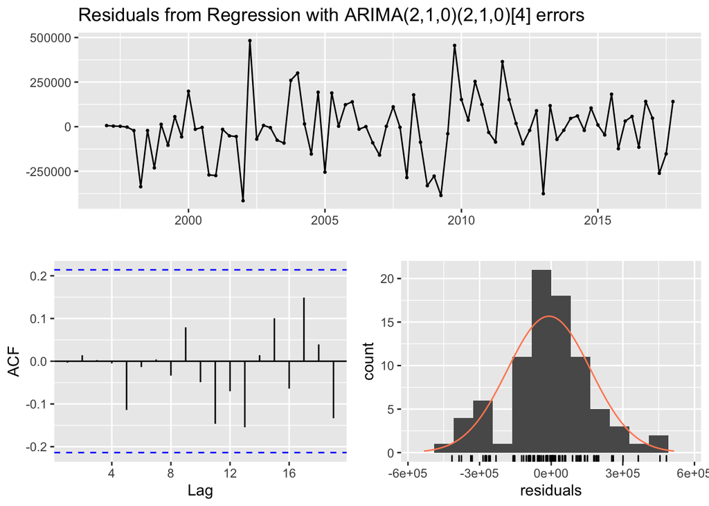

```
##
##  Ljung-Box test
##
## data:  Residuals from Regression with ARIMA(2,1,0)(2,1,0)[4] errors
## Q* = 1.3372, df = 3, p-value = 0.7203
##
## Model df: 5.   Total lags used: 8
```

```r
> checkresiduals(sarima.210.210.4)
```

Los residuales no tienen estructura; tienen media al rededor de cero, comportamiento aleatorio y autocorrelaciones no significativamente distintas de cero, parece ruido blanco lo que es lo que esperabamos. Así que validamos le modelo.

### Pronósticos

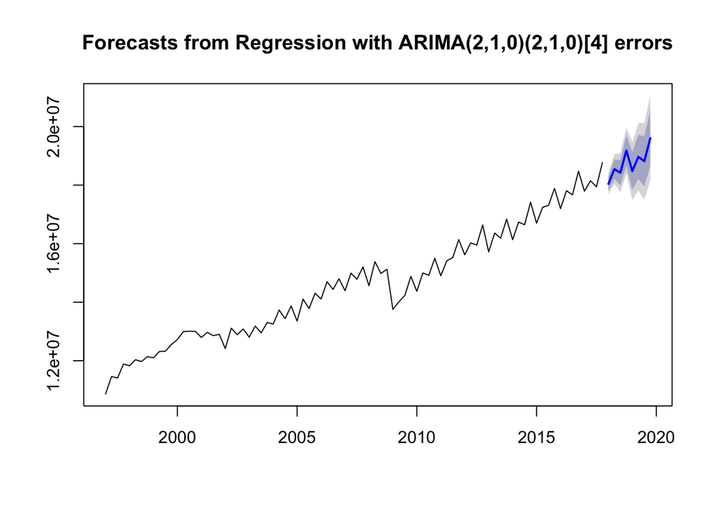

```r
> plot(forecast(sarima.210.210.4, h = 8, xreg = rep(0,8)))
```

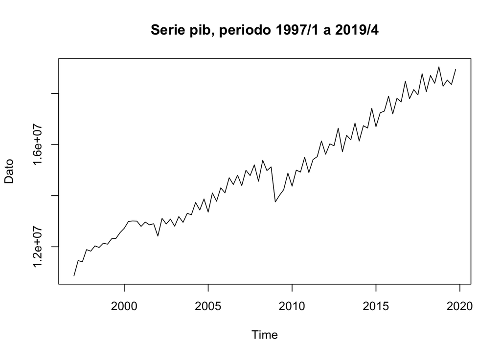

```r
> #Serie de tiempo con datos hasta 2019/04
> plot(ts(datospib[69:160,][,2], start = c(1997,1), frequency = 4),
+      main = "Serie pib, periodo 1997/1 a 2019/4")
```

### Conclusión

El modelo ganador por AIC y BIC (*$sarima.210.210.4$*) fue validado, contiene una indicadora para el periodo mayormente afectado por la crisis del 2008 (2009/01-2009/02) y fue un buen predictór de los datos realizados (2018/01-2019/04). Por lo que se da este análisis por concluido.